# BIO708 Assignment - Ian Dworkin

Shane

21/02/2024

## Project Data

```r
dd <- readRDS("PupBirthdaysClean.rds") # Note, the script used to make this file can be found in QMEE/data/Assignment02a.R
summary(dd)
```

```
##          Bat.ID   Sex       Birthday                  Group     Julian.Date
##  Sky101_M_O : 1   F:28   Min.   :2023-06-13   Captive    :17   Min.   :164.0
##  Sky103_F_G : 1   M:30   1st Qu.:2023-06-16   Wild-Caught:41   1st Qu.:167.0
##  Sky103_F_P : 1          Median :2023-06-17                    Median :168.5
##  Sky104_F_NC: 1          Mean   :2023-06-17                    Mean   :168.2
##  Sky104_M_NC: 1          3rd Qu.:2023-06-18                    3rd Qu.:169.0
##  Sky106_M_B : 1          Max.   :2023-06-22                    Max.   :173.0
##  (Other)    :52
##  Sib.Sex       Switch
##  F   :28   Min.   :2023-06-15
##  M   :26   1st Qu.:2023-06-18
##  NA's: 4   Median :2023-06-20
##            Mean   :2023-06-20
##            3rd Qu.:2023-06-22
##            Max.   :2023-06-25
##
```

**Note:** here is a brief explanation of the variables:

- **Bat.ID** is a subject identifier.
- **Sex** is the sex of the pup and is attributed to the variable Bat.ID.
- **Birthday** is a variable that represents the date (yyyy-mm-dd) which each pup was born.
- **Group** is a categorical factor, representing which group the pup was born into. Values include *Captive* and *Wild-Caught*. Note, *Wild-Caught* animals are pups born from moms caught at a maternity roost in southern Ontario, Canada about three weeks before parturition whereas *Captive* animals are pups born from moms that had been in captivity for an extended period of time during hibernation and prior to parturition.
- **Julian Date** corresponds to a different scale of birthday, taking into account that pups were all born within the same year (i.e. Julian Date goes from 0 [Jan 01] to 365 [Dec 31]),
- **Sib.Sex** is the sex of the pups sibling (if applicable). Note, is typical of big brown bats in eastern temperate North America to give birth to twins, (7) **Switch** is a variable that represents the first day the pup was found nursing on the opposite teat in which it was first observed nursing from.

## 1. Measurement

### Question 1a:

- **Theoretical Context:** We have reason to believe that the parturition date for animals can be influenced by time spent in captivity. In captivity, animals are closely monitored, typically given food *ad libitum*, and have controlled environments (e.g. lack of predators, humidity/temperature controlled rooms, etc.) Here, we recorded the birthdays of the pups born to two separate groups: Wild-Caught and Captive.
- **Empirical Relational Structure:** We measured birthday using calendar date (yyyy-mm-dd). Since all bats were born within the same year, we can transform the data into a continuous and meaningful scale - Julian Date - which represents the number of days elapsed since the beginning of the calendar year. Thus, this format sets a reference (i.e. 0 = 01-Jan-2023) and treats date as a continuous variable. **Note:** Although there is a zero value, this is not a ratio scale because the zero does not represent a lack of birthday.
- **Numerical Relational Structure:** Because we are using Julian Date, we can assess this variable on the interval scale. The Group factor (i.e. Captive or Wild-Caught) would be assessed on the nominal scale.
- **Meaningful Inferences:** Birthdays may be bimodally distributed between groups and the difference in birthdays may be meaningful (i.e. if pregnant females are acclimatized to captivity, this may affect when they give birth). I would infer that there may be some overlap between the distributions

### Question 1b:

Because *Group* is measured on a nominal scale, the only meaningful empirical operation I could use is assessing equivalence as any other comparison would require information that the measurement does not possess (e.g. magnitude). This scale does not permit calculations of means and variances as they would be meaningless. Note, I also use a measurement of *Sex* which is also on a nominal scale (it is also binomial, with values being either Male [M] or Female [F]). It may be interesting to examine the count / frequencies of male and female pups in my sample. To this account, I may also want to examine count / frequencies (and possibly mode) of pups in each *Group*.

Because *Birthday* is measured on an interval scale (i.e. the value of 0 does **not** mean a lack of the entity in question), it would be inappropriate to log-transform the data. Thus statements discussing ratio (e.g. there are 20% less…) would be meaningless as there is no true 0 defined. Even with the use of Julian Date (i.e. 0 = 01-Jan-2023), the value 0 still means that the pup would have a birthday - there is not a *lack of birthday*. The Julian Date transformation of data is meaningful and appropriate because the measurement remains unchanged (i.e. the distance between data points remain unchanged) and preserve the link between a measurement (now formatted as a continuous variable) and the reality they represent (a value indicating the day the animal was born relative to other animals, and within a calendar year).

## 2. Effect Sizes and Meaningful Magnitudes

### Question 2a:

Note, I will consider my continuous response variable to be *Julian.Date* and my predictors to be *Group* (either Captive or Wild-Caught) which can be found in the data frame *dd*

For this data, I am examining the difference between birthdays between two groups - Captive and Wild-caught animals - to see if there is a meaningful effect of group on birthday.

For this data, I believe the most appropriate measure of effect size would be **Cohen’s d**. Note, Cohen’s d scales the differences in mean between group by the pooled standard deviation, which serves as a measure of biological variation. This will be supplemented with an un-standairzied measure of difference in means (*See Question 2c for further explanation).

Note, the use of r statistics may be somewhat inappropriate as r statistics are usually used when the two variables are continuous whereas d statistics are used when the dependent variable is continuous and the idenedepnt variable is categorical, as is true in my data set. Note, it is possible - and relatively simple - to convert d statistics to r statistics if needed.

### Question 2b:

**Note:** Simply taking the difference between means can be a perfectly reasonable measure of effect. As long as the units are meaningful and comparable, this can be used. Below shows the difference between the two means of Wild-Caught and Captive bats:

```r
dd_diff_t_test <-t.test(Julian.Date ~ Group, alternative = "two.sided", data = dd)
t_useful_bits(dd_diff_t_test) # Note, the function t_useful_bits can be found in the slides provided by Ian Dworkin
```

```
##     mean in group Captive mean in group Wild-Caught                difference
##               166.9411765               168.7804878                 1.8393113
##                        SE                       CI1                       CI2
##                 0.5401022                -2.9462575                -0.7323651
##                        df
##                27.6687469
```

The difference in Means between Captive and Wild-Caught groups is 1.839, 95% CI [-2.946, -0.732].

This un-standardized measurement of effect size would be fine for this data. However, it limits the interpretation. For example, I may want to compare this data to other species of bats or even other mammals. These comparisons would be difficult given that meaningful scales may differ across different species. This rationale further explains why I chose to use **Cohen’s d**, because this measure of effect describes the differences in means (i.e. the general focus of my research question) while scaling by the pooled standard deviation (i.e. takes into consideration the biological variation within the sample). Scaling by standard deviation is usefu when the change you are examining may be interesting relative to th natural change observable in the population.

```r
library(effectsize)
cohens_d(Julian.Date ~ Group, data = dd)
```

```
## Cohen's d |         95% CI
## --------------------------
## -1.02     | [-1.61, -0.42]
##
## - Estimated using pooled SD.
```

Note, I would still want to report the differences in mean calculated above, for transparency. Standardized effects can be calcualted when sample siz and standard deviation are provided.

### Question 2c:

**I have chosen to use Cohen’s d as my effect size estimate.**

##### Benefits

One of the benefits of Cohen’s d measurements is that it can easily be converted into other forms of test statistics (e.g. r statistics). Furthermore, Cohen’s d is relatively easy to interpret when used appropriately, especially in the context of my research question (and most biological research questions). Cohen’s d is interpreted based on magnitude, where a relatively small value of Cohen’s d suggests a small effect size, where a large value represents a large effect size.

##### Drawbacks

One of the disadvantages to using Cohen’s d, contrary to whats stated above, is its interpretation. Cohen’s d does not provide useful informaiton on the units of measurement used to derive it. Nakagawa & Cuthill (2007) suggest that unstandardized effect measurements may be preferable. Using my data as an example where Cohen’s d = -1.02 (**Note:** the value is negative because the mean for the Captive group is smaller than the Wild-Caught group) and the 95% CI is -1.61 to -0.42, it would be meaningful and relevant to know how the measurement of age was scaled. In days? In minutes? In months? Changing this scale can change the interpretation of the Cohen’s d estimate. Therefore, it is critical to describe the units (in this case - **days**) used to derive the Cohen’s d estimate.

### Question 2d:

The following describes the development of a meaningful scale for data interpretation:

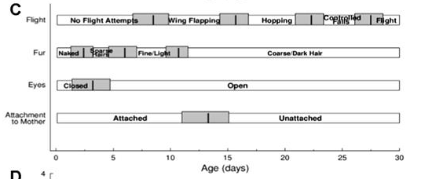

Figure 1: This Figure comes from Figure 1 in Mayberry and Faure (2014). It represents a timeline of important milestones in pup development for big brown bats. Horizontal bars represent different aspects of morphologial and behavioural changes: whether pup was found attached to the mother, the opening of the eyes, absence/presence of fur and type of haor, and flying ability. **black vertical lines** represent the mean age in days after birth when different milestones were achieved. *grey shading* represent +/- 1 standard deviation

A summary of these developmental milestones for big brown bats reportyed by Mayberry & Faure (2014) include:

- **Eyes:** eyes open at post natal dat (PND) 2/3
- **Hair:** grows sparse at PND 4, covers the body by PND 7/8, and becomes coarse by PND 8/9, and adult like-by PND 10/11
- **Flight:** pups make flight attempts around PND7/8 by flapping their wings while hanging. Pups begin hopping by PND 13, pefrom controlled falls / flight attempts by PND 21, and achieve true powered flight by PND 27/28.
- **Attachment to Mother:** pups tend to stop weaning by PND 13/14.

The authors suggest that “because newborn pups are altrical they are very dependent on their mother for nutrition, warmth and protection and are consistently found attached to and nursing from her until PND 13/14” (Mayberry and Faure, 2014). For these reasons, I will designate the meaningfully relevant measure of effect to be set at 14 days (i.e. 2 weeks) as the pups development would be drastically lagged. I would designate the grey area to start at 7 days (i.e. 1 week)

For this reason, I will focus on the positive measure of effect, but these regions would be symmetrical around 0. Based on the developmental milestones presented in Mayberry & Faure (2014), I would designate an effect size of 14 days to have meaningful biological relevance. **Note:** although inspired from the literature, these relevance splits were influenced by a humanistic interpretation (taking days on the order of weeks) and thus should be taken lightly, not as hard thresholds, when interpreting the data.

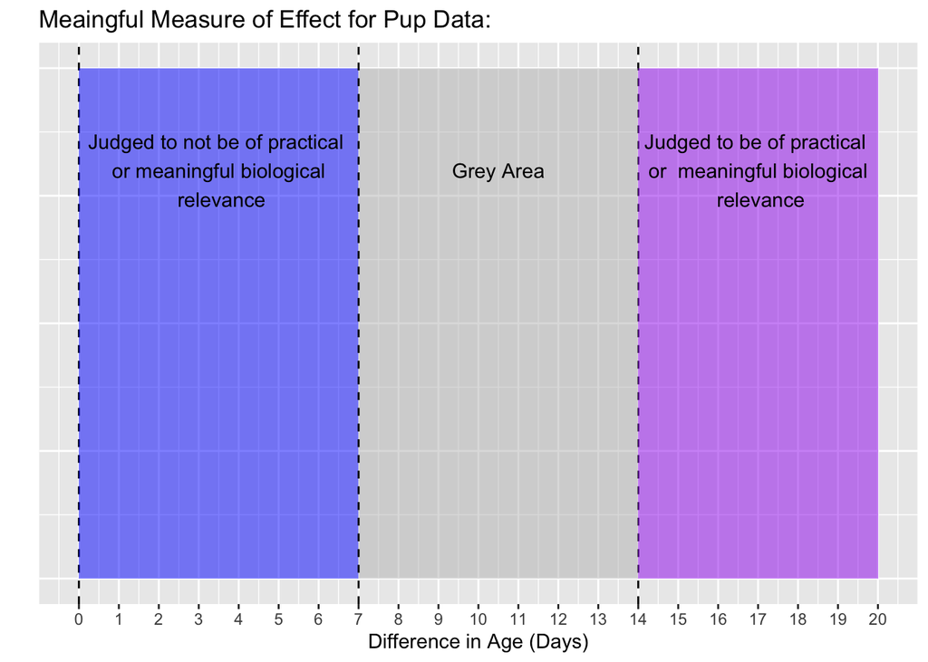

Figure 2: BoMM Figure created based on my own data

**Citation:** Mayberry, HW and Faure PA. (2014). Morphological, olfactory, and vocal development in big brown bats. *Biology Open* 4(1), 22-34.

### Question 2e:

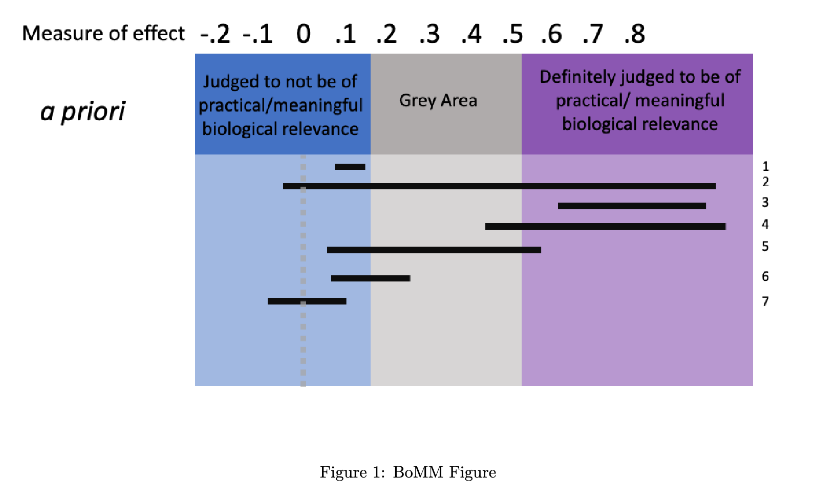

Figure 3: BoMM Figure included in Assignment

Below discusses my interpretation and inferences I would draw from the following estimates:

**Note:** Estimates 1, 3, 4, 5, and 6 would all be deemed statistically significant through means of null hypothesis significance testing (NHST), however there is a more meaningful interpretation of these estimates when attributed to a meaningful measure of effect.

**Note:** All estimates show an effect. From a biological perspective, it is not appropriate to say that there is no effect, even if the estimate crosses over the value 0. Viewing the 95% confidence intervals allow us to switch perspectives from *“Is there and effect”* to *“What is the effect?”*

- **Estimate 1:** This estimate is a small, positive effect of mutant type 1. However, this estimate is not considered **meaningful** in biological context. There is a lot of precision in this estimation (i.e. there is a high degree of certainty for this estimate).
- **Estimate 2:** This estimate is a large effect of mutant type 2. Note, it is not appropriate to say this estimate is positive, as the confidence interval overlaps 0. This estimate contains a wide range of values in all regions and thus possess a lot of **uncertainty**. One may be inclined to classify this estimate as meaningful, given that a large portion of the 95% CI spans this range. I believe this would be fine, but should be done with caution and explained in the context of the experiment (i.e. the theoretical context will aid in the authors interpretation, and providing this estimate will permit the reader to make an informed interpretation - either agreeing or disagreeing).
- **Estimate 3:** This estimate is a large, positive, and meaningful effect of mutant type 3. Note, the estimate has been deemed biologically meaningful based on observations within the field.
- **Estimate 4:** This estimate is also a large, positive, and arguably a meaningful effect of mutant type 4. Unlike Estimate 3, this estimate breaches into the *Grey Area*, suggesting that there is more uncertainty regarding the meaningfulness of this effect. However, it is important not to treat the boundaries between the different areas as definitive - otherwise you are essentially reproducing the same issues associated with significance testing (i.e. dichotomous decision, ‘p-value reliance’, etc.) within the effect size estimates. Note, the majority of the confidence interval breeches the *meaningful* bounds. Therefore, I would treat my interpretation of this estimate similar to that of Estimate 3.
- **Estimate 5:** This estimate is a small, positive effect of mutant type 5. The interpretation of estimate 5 should be done with caution because (1) the confidence intervals spread over multiple ranges including values that are not meaningful, grey area, and biologically meaningful values. In other words, there is a high degree of uncertainty associated with estimate 5. I would be interested to see where the estimate value lies within the 95% confidence interval (i.e. is it skewed in one direction), but I will assume that it lies in the middle - within the grey area. Note, the barriers of the Grey Area to other regions should be taken lightly and not as definitive thresholds (*See below*).
- **Estimate 6:** This estimate is a small, positive effect of mutant type 6, and is most similar to estimate 1. However, the interpretation of this estimate may differ slightly as it contains values in the *Grey Area* and might have different implications
- **Estimate 7:** This estimate is a relatively small effect of mutant type 7. Similar to estimate 2, it would be inappropriate to say this effect is positive/negative as the confidence intervals overlap 0.

Of course, I would not to make definitive conclusions off of levels of uncertainty (i.e. 95% confidence intervals) and instead make inferences from these estimates. I would also not want to make absolute thresholds of the barriers between regions (not meaningful, grey area, and meaningful) as this would be recreating the dichotomy problem associated with p-value decision making (loss of information). It is *important** to draw inferences from all of the information provided in estimate intervals.